# Setup

Descripción de las variables

- “userid”: Identificador único del browser de navegación.
- “date”: Fecha (YYYY-MM-DD) de la sesión actual
- “cant_actions”: Cantidad de eventos del usuario en la sesión previa
- “search”: Cantidad de eventos de búsqueda de la sesión previa
- “detail”: Cantidad de eventos de detalle de la sesión previa
- “checkout”: Cantidad de eventos de checkout de la sesión previa
- “thanks”: Cantidad de eventos de compra de la sesión previa
- “comprador”: Es la variable que queremos predecir, si compró o no algún hotel.
- “comprador_sess”: Si compró un hotel en la sesión previa
- “used_tablet”: Si el dispositivo usado es una tablet
- “used_smartphone”: Si el dispositivo usado es un celular
- “timeprox”: Distancia en milisegundos entre la sesión actual y la previa
- “longsess”: Duración en milisegundos de la sesión previa
- “cantsesiones”: Cantidad de sesiones previas a la actual en los últimos 15 días
- “dur_media”: Duración media (en segundos) de la estadía buscada en la sesión previa
- “ant_media”: Anticipación media (en segundos) entre la fecha de la sesión previa y las fechas de check-in buscadas

# Limpieza

```
<class 'pandas.core.frame.DataFrame'>
RangeIndex: 222989 entries, 0 to 222988
Data columns (total 16 columns):
userid             222881 non-null object
date               222989 non-null object
cant_actions       222989 non-null int64
search             222410 non-null float64
detail             222989 non-null int64
checkout           222989 non-null int64
thanks             222989 non-null int64
comprador          222989 non-null bool
comprador_sess     222989 non-null bool
used_tablet        222989 non-null object
used_smartphone    222859 non-null object
timeprox           222989 non-null int64
longsess           222989 non-null int64
cantsesiones       222989 non-null int64
dur_media          222989 non-null float64
ant_media          222989 non-null float64
dtypes: bool(2), float64(3), int64(7), object(4)
memory usage: 24.2+ MB
```

## Campos vacíos

```
userid             108
search             579
used_smartphone    130
dtype: int64
```

Sólo tres variables presentan valores nulos.  
Considero que la cantidad de registros afectados es despreciable.  
Como *userid* es un identificador y *used_smartphone* una columna de categoría, decido elimilar los registros con valores vacíos para esas variables.

En el caso de *search* compruebo las proporciones del target *comprador* para el dataset con y sin los registros donde *search* es nulo:

```
search nulo
```

```
False    0.968912
True     0.031088
Name: comprador, dtype: float64
```

```
search no-nulo
```

```
False    0.972443
True     0.027557
Name: comprador, dtype: float64
```

No considero significativa la diferencia.

```
90
```

Considerando que *cant_actions* sumariza los eventos, si la diferencia entre esa variable y la suma de los eventos identificados es cero, asumo que no hay eventos secundarios. Podría "salvar" 90 registros de esta forma.

También podría aplicar una imputación por la media de la variable; prefiero evitarlo por dado que se trata de un análisis multivariado.

Priorizo minimizar la manipulación de datos y eliminar también los registros para los cuales *search* es nula.

## Corrección de tipos (*dtypes*)

### *search*

Por la definición de la variable, considero debería ser tipo *int* y no *float*.

```
0
```

No hay ningún registro con valores decimales.  
Transformo la columna.

### *used_smartphone*

Por la definición de la variable, considero que *used_smartphone* debería ser tipo *bool* y no *object*.

```
True     135563
False     86610
Name: used_smartphone, dtype: int64
```

```
True     True
False    True
Name: used_smartphone, dtype: bool
```

### *used_tablet*

```
dfg      132826
False     88081
True       1266
Name: used_tablet, dtype: int64
```

```
51763
```

Esta variable presenta un valor desconocido para más de la mitad de los registros.  
Podría disminuir la cantidad de estos registros comparándola contra los casos positivos de la variable *used_smartphone*.  
Aún así, 51763 registros permanecerían con valor desconocido.

Prefiero descartar la variable y acotar el análisis a los dispositivos, *computadora* y *smartphone*.

## Chequeo de eventos

No hay registros donde *cant_actions* sea menor que la suma de los eventos principales.

```
0
```

## Agrego columnas auxiliares

# Exploración

## Período considerado

```
Inicio: 2018-05-14, Fin: 2018-06-12
```

## Total de sesiones por día de la semana

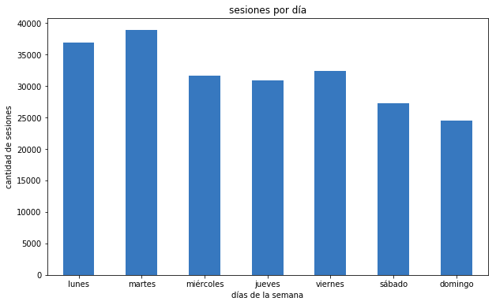

## Usuarios

```
Cantidad de usuarios únicos 98211.
```

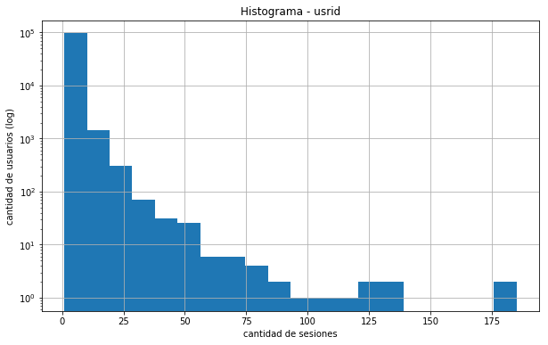

# Probabilidad de compra

Elijo el modelo KNeighbors para clasificar las sesiones registradas.  
Entreno al modelo con el 30% de los datos. Reservo un 70% para medir el rendimiento del mismo.

```
KNeighborsClassifier(algorithm='auto', leaf_size=30, metric='minkowski',
           metric_params=None, n_jobs=None, n_neighbors=5, p=2,
           weights='uniform')
```

Calculo las probabilidades

|  | mean |
| --- | --- |
| no_comprador_pred | 0.973723 |
| comprador_pred | 0.026277 |

```
Score del modelo: 0.9720
```

## Importancia de las variables

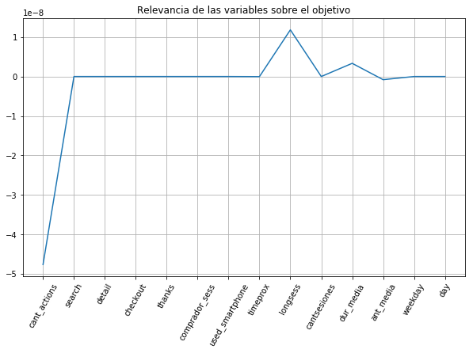

## Probabilidad en función de la cantidad de eventos

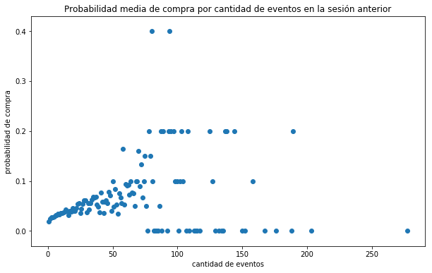

En el gráfico anterior excluyo a las sesiones con más de 400 eventos para una visualización más clara. Estas sesiones representan apenas un 6% del subset considerado.